# DrawdownNew

Andrew

2022-07-20

#This project examines drawdowns in the S&P 500 and attempts to build a model that can predict when the next month of returns (21 trading days) will be worse than -5%. The first part of the project loads price data for the S&P 500, HY Index Spreads, VIX, MOVE, and the 2/10 US Treasury Yield Curve. I run the PerformanceAnalytics package to visualize and display historical drawdowns in the S&P 500. From there, I build and test predictive models to help identify upcoming periods of greater than 5% losses over the next month.

```r
#Load required Bloomberg package and connect to the database. Create variables for start time and whether to include non-trading days
library(Rblpapi)
con<- blpConnect()
start_date <- as.Date("1940-08-20")
non_trade <- "FALSE"
```

```r
#load performance analytics package and dplyr
library(PerformanceAnalytics)
library(dplyr)
#Load kable package for fancy tables
library(kableExtra)
```

```r
#Load Bloomberg data of historical S&P 500 prices
spx <- bdh(securities = "SPX Index",
           fields = "PX_LAST",
           start.date = start_date,include.non.trading.days = non_trade)
```

```r
#Create Bloomberg function to quickly retrieve data. Ticker = Bloomberg ticker, variable = Bloomberg data field, start = start date of data, days = whether to include non-trading days
bloom<- function(ticker,variable,start,days){
  result<- bdh(securities = ticker,
               fields = variable,
               start.date = start,
               include.non.trading.days = days)
  return(result)
}
```

```r
#Retrieve data for drawdown model
high_yield<- bloom("LF98OAS Index", "PX_LAST", start_date,non_trade)
vix<- bloom("VIX Index","PX_LAST",start_date,non_trade)
move<- bloom("MOVE Index", "PX_LAST", start_date, non_trade)
yield_curve<- bloom("USYC2Y10 Index", "PX_LAST", start_date, non_trade)
```

```r
#Convert Bloomberg dataframes to xts time based objects
hy_xts<- xts(high_yield[,-1], order.by = high_yield$date)
vix_xts<- xts(vix[,-1], order.by = vix$date)
move_xts<- xts(move[,-1],order.by = move$date)
yc_xts<- xts(yield_curve[,-1], order.by = yield_curve$date)
```

```r
#Convert spx to and xts time based object
spx_xts<- xts(spx[,-1], order.by = spx$date)
colnames(spx_xts)[1]<- "PX_LAST"
```

```r
#Create column calculating daily returns
spx_xts$daily_return<- ((spx_xts$PX_LAST/stats::lag(spx_xts,1))-1)
```

```r
#Create a window of spx_xts that contains return data for each day (excludes a single day from original dataset)
spx_40<- window(spx_xts["1940-08-21/"])
```

```r
#run table.drawdowns on S&P 500
d_downs<- table.Drawdowns(spx_40$daily_return, top = 50)
```

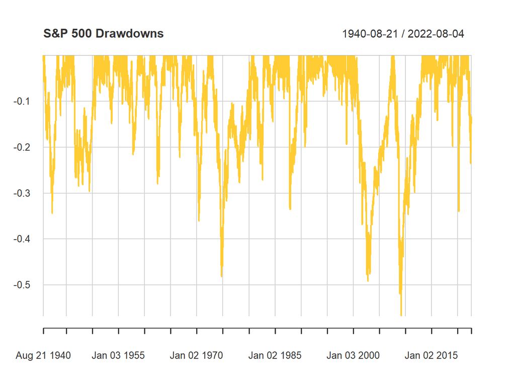

```r
#Chart S&P 500 Drawdowns
chart.Drawdown(spx_40$daily_return, color = "#FFCC33", lwd = 0.5, main = "S&P 500 Drawdowns")
```

```r
#Create ratio between length of recovery to drawdown
d_downs$recover_trough_ratio<- d_downs$Recovery/d_downs$`To Trough`
```

```r
#Merge all xts objects into one dataset
all<- merge(hy_xts,vix_xts,move_xts,yc_xts,spx_xts)
```

```r
#Create a subset of the all dataset where each variable has consistent daily data
all_2000<- window(all["2000-08-15/"])

#Carry last observation forward to remove NA
all_2000<- na.locf(all_2000)
```

```r
#Add new data mutations to the dataset
all_2000$hy_chg<- all_2000$hy_xts - stats::lag(all_2000$hy_xts,126)
all_2000$vix_chg<- all_2000$vix_xts - stats::lag(all_2000$vix_xts,21)
all_2000$move_chg<- all_2000$move_xts - stats::lag(all_2000$move_xts,21)
all_2000$spx_month<- (all_2000$PX_LAST/stats::lag(all_2000$PX_LAST,21))-1
all_2000$lead_returns<- stats::lag(all_2000$spx_month,-21)
all_2000$spx_bad<- all_2000$lead_returns < -0.05
```

```r
#Split dataset into train, validate, test sets
train<- window(all_2000["2001-02-07/2011-02-06"])
valid<- window(all_2000["2011-02-07/2016-02-06"])
test<- window(all_2000["2016-02-07/2022-06-22"])
```

```r
##First Logistic regression model for the data
dd_glm<- glm(spx_bad ~ hy_chg + vix_chg + move_chg + yc_xts, data = train, family = binomial(link = "logit"))
summary(dd_glm)
```

```
##
## Call:
## glm(formula = spx_bad ~ hy_chg + vix_chg + move_chg + yc_xts,
##     family = binomial(link = "logit"), data = train)
##
## Deviance Residuals:
##     Min       1Q   Median       3Q      Max
## -1.7272  -0.5215  -0.4546  -0.3952   2.3906
##
## Coefficients:
##               Estimate Std. Error z value Pr(>|z|)
## (Intercept) -2.4140595  0.1288696 -18.733  < 2e-16 ***
## hy_chg       0.1509113  0.0184080   8.198 2.44e-16 ***
## vix_chg     -0.0024684  0.0097006  -0.254 0.799137
## move_chg     0.0153274  0.0032138   4.769 1.85e-06 ***
## yc_xts       0.0026248  0.0007011   3.744 0.000181 ***
## ---
## Signif. codes:  0 '***' 0.001 '**' 0.01 '*' 0.05 '.' 0.1 ' ' 1
##
## (Dispersion parameter for binomial family taken to be 1)
##
##     Null deviance: 1984.6  on 2607  degrees of freedom
## Residual deviance: 1875.3  on 2603  degrees of freedom
## AIC: 1885.3
##
## Number of Fisher Scoring iterations: 5
```

```r
##Using fitted model to predict on validation set, summary of drawdown prediction ranges
dd_predict<- predict(dd_glm,valid, type = "response")
summary(dd_predict)
```

```
##    Min. 1st Qu.  Median    Mean 3rd Qu.    Max.
## 0.06724 0.10886 0.12506 0.12979 0.14360 0.24568
```

#The initial above predictions show that the model assigns anywhere from 6.724% to 24.568% to a forthcoming drawdown

```r
library(pROC)
roc(as.matrix(valid$spx_bad),round(dd_predict))
```

```
##
## Call:
## roc.default(response = as.matrix(valid$spx_bad), predictor = round(dd_predict))
##
## Data: round(dd_predict) in 1215 controls (as.matrix(valid$spx_bad) 0) < 90 cases (as.matrix(valid$spx_bad) 1).
## Area under the curve: 0.5
```

```r
##Setting threshold probability for the model and looking at the confusion matrix
thresh<- 0.2
dd_predict_thresh<- as.integer(dd_predict> thresh)
(conf_matrix<- as.matrix(table(dd_predict_thresh, valid$spx_bad)))
```

```
##
## dd_predict_thresh    0    1
##                 0 1176   88
##                 1   39    2
```

#After setting the prediction threshold to 20%, the model correctly predicts 1176 “good months” where the S&P 500 avoids a drawdown of at least 5% and capturing two months where a drawdown of more than 5% happened. The model peformed poorly otherwise, calling for 39 months of drawdowns when none actually occured and missing 88 months of actual drawdowns. In the next step, I will create a threshold level (minimum probability to predict a drawdown) and see how the model fares.

```r
##Creating a vector of thresholds. The models predicted values range from 0.06724 to 0.24568
thresh_seq<- seq(0.08,0.24,0.01)
```

```r
##Creating function to compare several threshold levels in the model
thresh_func<- function(x){
  pt<- as.integer(dd_predict>x)
  return(pt)
}
```

```r
##Applying threshold function across vector of thresholds
thresholds<-lapply(thresh_seq, thresh_func)
```

```r
##Function to create confusion matrices across all thresholds
cm_func<- function(y){
  mtx<- as.matrix(table(y,valid$spx_bad))
  return(mtx)
}
```

```r
##Applying confusion matrix function to see confusion matrix for each threshold
(thresh_mtx<- lapply(thresholds,cm_func))
```

```
## [[1]]
##
## y      0    1
##   0   20    3
##   1 1195   87
##
## [[2]]
##
## y      0    1
##   0   62    7
##   1 1153   83
##
## [[3]]
##
## y      0    1
##   0  168   13
##   1 1047   77
##
## [[4]]
##
## y     0   1
##   0 328  22
##   1 887  68
##
## [[5]]
##
## y     0   1
##   0 510  27
##   1 705  63
##
## [[6]]
##
## y     0   1
##   0 741  34
##   1 474  56
##
## [[7]]
##
## y     0   1
##   0 874  50
```

[output cut: 46 more lines]

```
## y      0    1
##   0 1201   90
##   1   14    0
##
## [[16]]
##
## y      0    1
##   0 1208   90
##   1    7    0
##
## [[17]]
##
## y      0    1
##   0 1214   90
##   1    1    0
```

```r
#Create an accuracy function to apply to each threshold matrix
accuracy<- function(x){
  acc<- (x[1,1] + x[2,2])/sum(x)
  return(acc)
}
```

```r
#Calculate the accuracy of each matrix
(result<- lapply(thresh_mtx, accuracy))
```

```
## [[1]]
## [1] 0.08199234
##
## [[2]]
## [1] 0.1111111
##
## [[3]]
## [1] 0.1877395
##
## [[4]]
## [1] 0.3034483
##
## [[5]]
## [1] 0.4390805
##
## [[6]]
## [1] 0.610728
##
## [[7]]
## [1] 0.7003831
##
## [[8]]
## [1] 0.7808429
##
## [[9]]
## [1] 0.8130268
##
## [[10]]
## [1] 0.8421456
##
## [[11]]
## [1] 0.8697318
##
## [[12]]
## [1] 0.8850575
##
## [[13]]
## [1] 0.902682
##
## [[14]]
## [1] 0.9088123
##
## [[15]]
## [1] 0.9203065
##
## [[16]]
## [1] 0.9256705
##
## [[17]]
## [1] 0.9302682
```

```r
acc_df<- t(as.data.frame(result,col.names = thresh_seq))
acc_df <- cbind(newColName = rownames(acc_df), acc_df)
rownames(acc_df) <- 1:nrow(acc_df)
```

```r
#Create fancy table of accuracy level at each threshold
kable(acc_df, col.names = c("Threshold Level","Model Accuracy"))
```

| Threshold Level | Model Accuracy |
| --- | --- |
| X0.08 | 0.081992337164751 |
| X0.09 | 0.111111111111111 |
| X0.1 | 0.187739463601533 |
| X0.11 | 0.303448275862069 |
| X0.12 | 0.439080459770115 |
| X0.13 | 0.610727969348659 |
| X0.14 | 0.700383141762452 |
| X0.15 | 0.780842911877395 |
| X0.16 | 0.813026819923372 |
| X0.17 | 0.842145593869732 |
| X0.18 | 0.869731800766284 |
| X0.19 | 0.885057471264368 |
| X0.2 | 0.902681992337165 |
| X0.21 | 0.908812260536399 |
| X0.22 | 0.920306513409962 |
| X0.23 | 0.925670498084291 |
| X0.24 | 0.930268199233717 |

#The above table shows that at low prediction threshold probabilities, the model incorrectly calls for too many drawdowns, when in fact the actual s&P 500 return was not worse than -5%. At higher prediction threshold probabilities, the model correctly classified non-drawdown months, but failed to identify most (if any) of the actual drawdowns. In the next step, I will apply a cost function that penalizes the model for incorrectly classifying drawdowns and missing actual drawdowns.

#The cost function will calculate each thresholds “cost” to an investor for model errors. For type one errors, where the model calls for no drawdown and there actually is a drawdown, I will start by weighting those errors 10X. Type two errors, where the model calls for a drawdown, but the actual S&P 500 return is better than -5%, I will take at face value.

```r
##Creating a cost function
cost_per_thresh<- function(x){
  cpt<- (10 * x[1,2]) + (x[2,1])
  return(cpt)
}
```

```r
##Applying the cost function across all threshold confusion matrices
lapply(thresh_mtx,cost_per_thresh)
```

```
## [[1]]
## [1] 1225
##
## [[2]]
## [1] 1223
##
## [[3]]
## [1] 1177
##
## [[4]]
## [1] 1107
##
## [[5]]
## [1] 975
##
## [[6]]
## [1] 814
##
## [[7]]
## [1] 841
##
## [[8]]
## [1] 826
##
## [[9]]
## [1] 829
##
## [[10]]
## [1] 872
##
## [[11]]
## [1] 881
##
## [[12]]
## [1] 933
##
## [[13]]
## [1] 919
##
## [[14]]
## [1] 920
##
## [[15]]
## [1] 914
##
## [[16]]
## [1] 907
##
## [[17]]
## [1] 901
```

#The above cost for each threshold level identifies a model threshold predition probability of 13% as the best. I will now apply the model to the test data using 13% prediction probability to see how it works.

```r
##Using fitted model to predict on validation set, summary of drawdown prediction ranges
dd_predict_test<- predict(dd_glm,test, type = "response")
summary(dd_predict_test)
```

```
##    Min. 1st Qu.  Median    Mean 3rd Qu.    Max.
## 0.03745 0.08304 0.09269 0.09698 0.10443 0.41529
```

```r
##Setting threshold probability for the model and looking at the confusion matrix
thresh_test<- 0.13
dd_predict_test_thresh<- as.integer(dd_predict_test> thresh_test)
(conf_matrix_test<- as.matrix(table(dd_predict_test_thresh, test$spx_bad)))
```

```
##
## dd_predict_test_thresh    0    1
##                      0 1444  117
##                      1   90   12
```

```r
#Calculating the accuracy of the model in the test period
accuracy(conf_matrix_test)
```

```
## [1] 0.8755262
```

#Using test data, the model correctly classified 1444 no drawdown periods and identified 12 actual drawdowns greater than -5%. The model incorrectly labeled 90 periods as drawdowns when none actually occured and failed to identify 117 actual drawdowns. Overall, the model’s accuracy was 87% on test data.